# 8 Online Appendix E

## 8.1 Setup

### 8.1.1 Install Packages

We install the following packages using the `groundhog` package manager to increase computational reproducibility.

```r
if (!requireNamespace("groundhog", quietly = TRUE)) {
    install.packages("groundhog")
    library("groundhog")
}

pkgs <- c("magrittr", "data.table", "stringr", "Rmisc", "ggplot2", "patchwork",
          "rstatix", "ggpubr", "glue", "lubridate", "plyr",
          "lmtest", "sandwich", "stargazer" # packages for regression tables
          )

groundhog::groundhog.library(pkg = pkgs,
                             date = "2023-09-25")
```

### 8.1.2 Read Data

```r
# data <- data.table::fread(file = "../data/processed/full.csv")
data <- readRDS(file="../data/processed/full.Rda")
```

### 8.1.3 Manipulate Data

`[Shall we add this code chunk to the pre-processing?]`

```r
data[, communication := as.factor(communication)]
data[, communication := factor(communication, levels = c("point", "both","interval"))]
data[, stage := as.factor(stage)]
data[, stage := factor(stage, levels = c("1", "2"))]
```

```r
cols <- str_subset(string = names(data), pattern = "E\\d+")
data[,
     str_replace_all(string = cols, pattern = "^E", replacement = "m") := lapply(.SD, function(x) x / 100),
     .SDcols = cols]

data[, p1 := 0.5 + (m1 - m23)/ (6*(mc-ms))]
data[, p2 := 0.5 + (m2 - m13)/ (6*(mc-ms))]
data[, p3 := 0.5 + (m3 - m12)/ (6*(mc-ms))]
```

```r
strict_violators <- data[a >= 1 |
                           E1 > E12 | E1 > E13 |
                           E2 > E12 | E2 > E23 |
                           E3 > E13 | E3 > E23,
                         unique(participant.label)]
subset <- data[!(participant.label %in% strict_violators)]
```

```r
wide_subset <- data.table::dcast(subset,
                                 participant.label + surprise + communication ~ stage,
                                 value.var = c("p1", "p2", "p3"))

setorder(wide_subset, surprise, communication, participant.label)
```

```r
wide_subset[, euclidian_distance := sqrt((p1_1 - p1_2)^2 +
                                           (p2_1 - p2_2)^2 +
                                           (p3_1 - p3_2)^2)]
```

### 8.1.4 Design

We define some design features in the following:

```r
colors <- c("#F3B05C", "#1E4A75", "#65B5C0", "#AD5E21")

layout <- theme(panel.background = element_rect(fill = "white"),
                legend.key = element_rect(fill = "white"),
                panel.grid.major.y = element_line(colour = "grey",
                                                  linewidth = 0.25),
                axis.ticks.y = element_blank(),
                panel.grid.major.x = element_blank(),
                axis.line.x.bottom = element_line(colour = "#000000",
                                                  linewidth = 0.5),
                axis.line.y.left = element_blank(),
                plot.title = element_text(size = rel(1))
)
```

### 8.1.5 Helper Function

```r
plot_bars2 <- function(data, response = "p", surprise_sub = NA, limits = ylim(-0.05, 1.02)){

  if(response == "p1" | response == "p2" | response == "p3"){
      y_1 = 0.6
      y_2 = 0.4
    } else {
      y_1 = 1.4
      y_2 = 1
    }

  if(!is.na(surprise_sub)){
    # Plot bottom panels
    tmp <- data[data$surprise == surprise_sub, ]
    names(tmp)[names(tmp) == response] <- 'outcome'

    if(surprise_sub){
      title <- "Surprising Condition"
    } else {
      title <- "Confirming Condition"
    }

    test_stats_1 <- tmp %>%
      dplyr::group_by(communication) %>%
      rstatix::wilcox_test(formula = outcome ~ stage, paired = TRUE) %>%
      rstatix::adjust_pvalue(method = "none") %>%
      rstatix::add_significance(p.col = "p.adj",
                       cutpoints = c(0, 0.01, 0.05, 0.1, 1),
                       symbols = c("***", "**", "*", "ns")) %>%
      dplyr::as_tibble()

    test_stats_2 <- tmp %>%
      dplyr::group_by(stage) %>%
      rstatix::wilcox_test(formula = outcome ~ communication) %>%
      rstatix::adjust_pvalue(method = "none") %>%
      rstatix::add_significance(p.col = "p.adj",
                       cutpoints = c(0, 0.01, 0.05, 0.1, 1),
                       symbols = c("***", "**", "*", "ns")) %>%
      dplyr::as_tibble()

    test_stats_2 <- test_stats_2[test_stats_2$stage == 2, ]

    plot_bottom <- ggplot2::ggplot(data = tmp,
           mapping = ggplot2::aes(x = as.factor(communication), y = outcome)) +
        ggplot2::geom_bar(ggplot2::aes(fill = stage),
                 position = "dodge",
                 stat = "summary",
                 fun = "mean") +
      limits +
      ggplot2::scale_fill_manual(values=c("black", "gray")) +
      ggplot2::theme_classic() +
      ggpubr::stat_pvalue_manual(data = test_stats_2,
                         label = "{p} ({p.adj.signif})",
                         step.group.by = "stage",
                         tip.length = 0,
                         step.increase = 0.1,
                         y.position = y_1) +
      ggpubr::stat_pvalue_manual(data = test_stats_1,
                         label = "{p} ({p.adj.signif})",
                         y.position = y_2,
                         tip.length = 0,
                         x = "communication") +
      ggplot2::labs(title = title, x = "Communication", y = glue::glue("{response}"))

    rm(tmp)

    return(plot_bottom)
  } else {
    # Plot the top panel
    tmp <- data
    names(tmp)[names(tmp) == response] <- 'outcome'

    title <- "Both Conditions"

    test_stats_1 <- tmp %>%
      dplyr::group_by(surprise) %>%
      rstatix::wilcox_test(formula = outcome ~ stage, paired = TRUE) %>%
      rstatix::adjust_pvalue(method = "none") %>%
      rstatix::add_significance(p.col = "p.adj",
                       cutpoints = c(0, 0.01, 0.05, 0.1, 1),
                       symbols = c("***", "**", "*", "ns")) %>%
      dplyr::as_tibble()

    test_stats_2 <- tmp %>%
      dplyr::group_by(stage) %>%
      rstatix::wilcox_test(formula = outcome ~ surprise) %>%
      rstatix::adjust_pvalue(method = "none") %>%
      rstatix::add_significance(p.col = "p.adj",
                       cutpoints = c(0, 0.01, 0.05, 0.1, 1),
                       symbols = c("***", "**", "*", "ns")) %>%
      dplyr::as_tibble()

    test_stats_2 <- test_stats_2[test_stats_2$stage == 2, ]

    plot_top <- ggplot2::ggplot(data = tmp,
           mapping = ggplot2::aes(x = as.factor(surprise), y = outcome)) +
        ggplot2::geom_bar(ggplot2::aes(fill = stage),
                 position = "dodge",
                 stat = "summary",
                 fun = "mean") +
      limits +
      ggplot2::scale_fill_manual(values=c("black", "gray")) +
      ggplot2::theme_classic() +
      ggpubr::stat_pvalue_manual(data = test_stats_2,
                         label = "{p} ({p.adj.signif})",
                         step.group.by = "stage",
                         tip.length = 0,
                         step.increase = 0.1,
                         y.position = y_1) +
      ggpubr::stat_pvalue_manual(data = test_stats_1,
                         label = "{p} ({p.adj.signif})",
                         y.position = y_2,
                         tip.length = 0,
                         x = "surprise") +
      ggplot2::labs(title = title, x = " Surprising Condition", y = glue::glue("{response}"))

    rm(tmp)

    return(plot_top)
  }
}
```

## 8.2 Figures & Tables

We now consider the effects of information on so-called ambiguity neutral probabilities which have been suggested in Li, Turmunkh, and Wakker (2019). This analysis complements the investigations on the effect on the probability equivalents for the individual events that are discussed in the main part of the paper.

Ambiguity-neutral probabilities are calculated according to equation (3.3) from Li, Turmunkh, and Wakker (2019, 56) which we simplify as follows:

$$\begin{align*}
p_1&=\frac{3(\overline{m_c}-\overline{m_s})+3m_1-3m_{23}+2(1-a)}{6(1-a)}\\
&=\frac{3(\overline{m_c}-\overline{m_s})+3m_1-3m_{23}+2(1-(3 \times (\frac{1}{3} -(\overline{m_c}-\overline{m_s}))))}{6(1-(3 \times (\frac{1}{3} -(\overline{m_c}-\overline{m_s}))))}\\
&=\frac{1}{2}+\frac{m_1-m_{23}}{6(\overline{m_c}-\overline{m_s})}.
\end{align*}$$

The structure of the presentation of results follows the discussion in the main part of the paper.

### 8.2.1 Figure OE.1

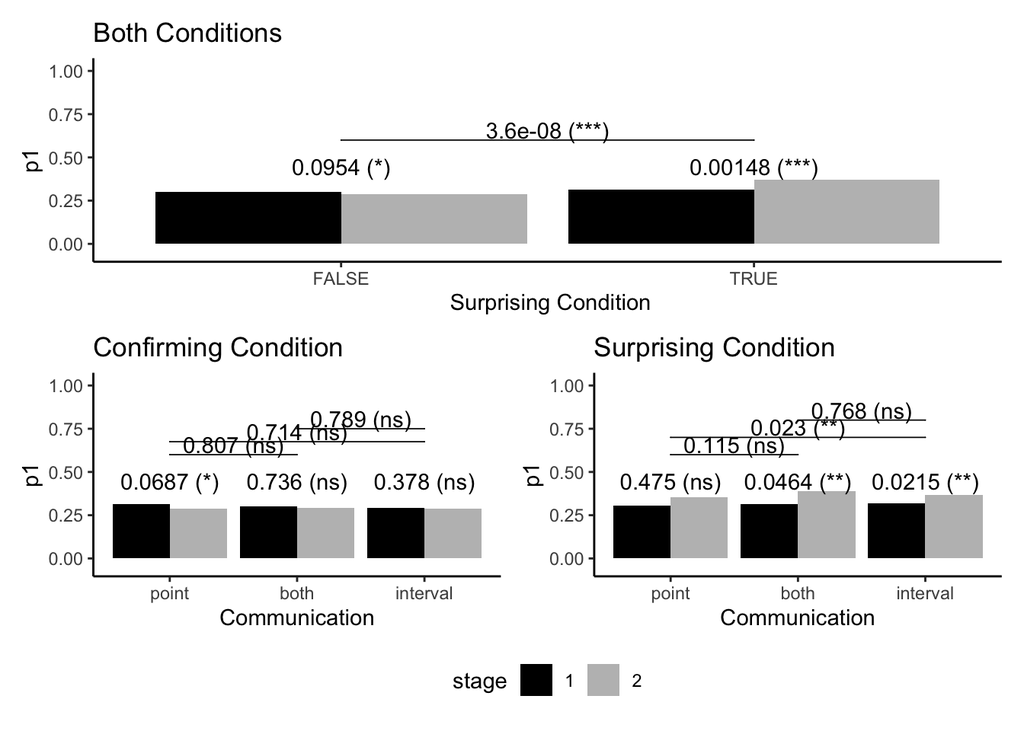

Figure 8.1: A-neutral probability $p_1$ separated by treatments and part 1 and part 2. P-values of Wilcoxon signed-rank test comparing part 1 and 2 directly above the mean values. P-values of Wilcoxon–Mann–Whitney test comparing part 2 of different treatments at the top. Note: $^{*}$p$<$0.10, $^{**}$p$<$0.05, $^{***}$p$<$0.01, ns: not significant

```r
top   <- plot_bars2(data = subset, response = "p1", surprise_sub = NA)
left  <- plot_bars2(data = subset, response = "p1", surprise_sub = FALSE)
right <- plot_bars2(data = subset, response = "p1", surprise_sub = TRUE)

(top / (left | right) & theme(legend.position = "bottom")) + plot_layout(guides = "collect")
```

### 8.2.2 Figure OE.2

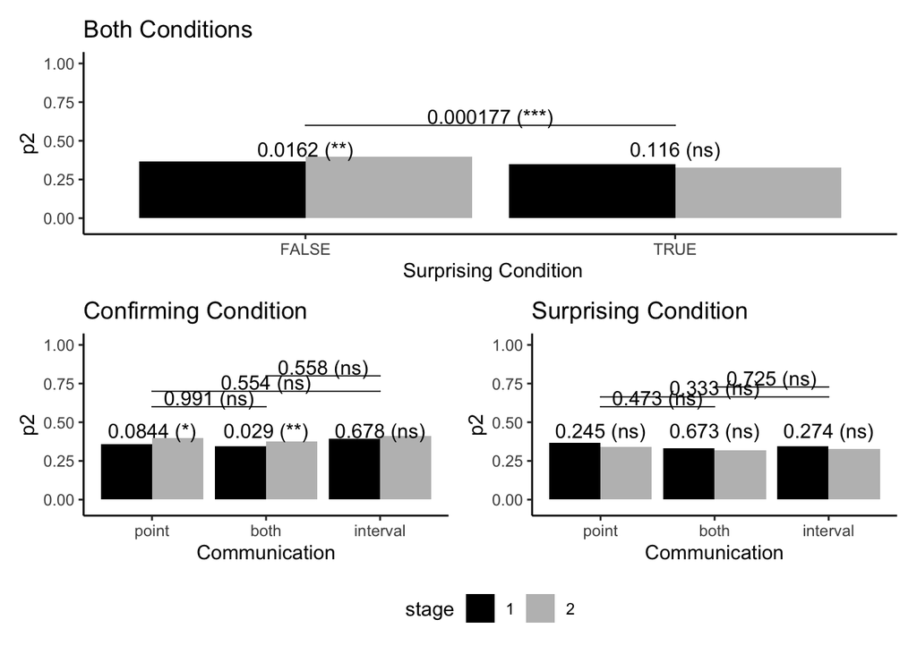

Figure 8.2: A-neutral probability $p_2$ separated by treatments and part 1 and part 2. P-values of Wilcoxon signed-rank test comparing part 1 and 2 directly above the mean values. P-values of Wilcoxon–Mann–Whitney test comparing part 2 of different treatments at the top. Note: $^{*}$p$<$0.10, $^{**}$p$<$0.05, $^{***}$p$<$0.01, ns: not significant

```r
top   <- plot_bars2(data = subset, response = "p2", surprise_sub = NA)
left  <- plot_bars2(data = subset, response = "p2", surprise_sub = FALSE)
right <- plot_bars2(data = subset, response = "p2", surprise_sub = TRUE)

(top / (left | right) & theme(legend.position = "bottom")) + plot_layout(guides = "collect")
```

### 8.2.3 Figure OE.3

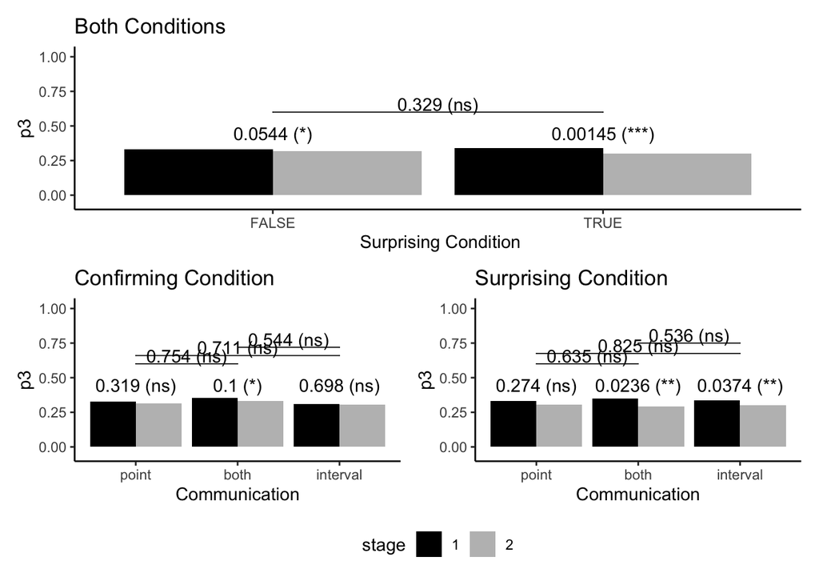

Figure 8.3: A-neutral probability $p_3$ separated by treatments and part 1 and part 2. P-values of Wilcoxon signed-rank test comparing part 1 and 2 directly above the mean values. P-values of Wilcoxon–Mann–Whitney test comparing part 2 of different treatments at the top. Note: $^{*}$p$<$0.10, $^{**}$p$<$0.05, $^{***}$p$<$0.01, ns: not significant

```r
top   <- plot_bars2(data = subset, response = "p3", surprise_sub = NA)
left  <- plot_bars2(data = subset, response = "p3", surprise_sub = FALSE)
right <- plot_bars2(data = subset, response = "p3", surprise_sub = TRUE)

(top / (left | right) & theme(legend.position = "bottom")) + plot_layout(guides = "collect")
```

### 8.2.4 Table OE.1

```r
ols_1 <- lm(formula = p1 ~ surprise + treated + surprise * treated,
              data = subset)
  se_1  <- coeftest(x = ols_1,
                    vcov = vcovCL(ols_1,
                                  cluster = subset[, participant.label],
                                  type = "HC1"))

  ols_2 <- lm(formula = p1 ~ communication + treated + communication * treated,
              data = subset,
              subset = (surprise == FALSE))
  se_2  <- coeftest(x = ols_2,
                    vcov = vcovCL(ols_2,
                                  cluster = subset[surprise == FALSE, participant.label],
                                  type = "HC1"))

  ols_3 <- lm(formula = p1 ~ communication + treated + communication * treated,
              data = subset,
              subset = (surprise == TRUE))
  se_3  <- coeftest(x = ols_3,
                    vcov = vcovCL(ols_3,
                                  cluster = subset[surprise == TRUE, participant.label],
                                  type = "HC1"))

  ols_4 <- lm(formula = p1 ~ surprise + treated + surprise * treated,
              data = subset,
              subset = (communication == "point"))
  se_4  <- coeftest(x = ols_4,
                    vcov = vcovCL(ols_4,
                                  cluster = subset[communication == "point", participant.label],
                                  type = "HC1"))

  ols_5 <- lm(formula = p1 ~ surprise + treated + surprise * treated,
              data = subset,
              subset = (communication == "interval"))
  se_5  <- coeftest(x = ols_5,
                    vcov = vcovCL(ols_5,
                                  cluster = subset[communication == "interval", participant.label],
                                  type = "HC1"))

  ols_6 <- lm(formula = p1 ~ surprise + treated + surprise * treated,
              data = subset,
              subset = (communication == "both"))
  se_6  <- coeftest(x = ols_6,
                    vcov = vcovCL(ols_6,
                                  cluster = subset[communication == "both", participant.label],
                                  type = "HC1"))



  se <- list(se_1[,2], se_2[,2], se_3[,2], se_4[,2], se_5[,2], se_6[,2])
  p  <- list(se_1[,4], se_2[,4], se_3[,4], se_4[,4], se_5[,4], se_6[,4])

  stargazer(ols_1, ols_2, ols_3, ols_4, ols_5, ols_6,
            align = TRUE,
            se = se,
            p = p,
            title = "Linear regressions: Treatment effects on p1",
            model.names = FALSE,
            column.labels = c("full", "confirmation", "contradiction", "point", "interval", "both"),
            covariate.labels = c("contradiction", "both", "interval", "part2", "contradiction x stage 2", "both x stage2", "interval x stage2", "Constant"),
            font.size = "scriptsize",
            type = "html",
            df = FALSE,
            style = "qje")
```

**Linear regressions: Treatment effects on p1**

|  | p1 |  |  |  |  |  |
| --- | --- | --- | --- | --- | --- | --- |
|  | full | confirmation | contradiction | point | interval | both |
|  | (1) | (2) | (3) | (4) | (5) | (6) |
| contradiction | 0.010 |  |  | -0.009 | 0.024 | 0.014 |
|  | (0.011) |  |  | (0.019) | (0.019) | (0.019) |
| both |  | -0.012 | 0.011 |  |  |  |
|  |  | (0.019) | (0.018) |  |  |  |
| interval |  | -0.020 | 0.012 |  |  |  |
|  |  | (0.022) | (0.015) |  |  |  |
| part2 | -0.014 | -0.026* | 0.049** | -0.026* | -0.008 | -0.009 |
|  | (0.009) | (0.015) | (0.023) | (0.015) | (0.016) | (0.016) |
| contradiction x stage 2 | 0.071*** |  |  | 0.075*** | 0.059** | 0.082** |
|  | (0.017) |  |  | (0.028) | (0.026) | (0.033) |
| both x stage2 |  | 0.017 | 0.024 |  |  |  |
|  |  | (0.022) | (0.037) |  |  |  |
| interval x stage2 |  | 0.019 | 0.003 |  |  |  |
|  |  | (0.022) | (0.031) |  |  |  |
| Constant | 0.302*** | 0.313*** | 0.305*** | 0.313*** | 0.293*** | 0.302*** |
|  | (0.008) | (0.016) | (0.010) | (0.016) | (0.015) | (0.011) |
| *N* | 610 | 298 | 312 | 192 | 226 | 192 |
| R<sup>2</sup> | 0.074 | 0.008 | 0.066 | 0.050 | 0.082 | 0.100 |
| Adjusted R<sup>2</sup> | 0.070 | -0.009 | 0.050 | 0.035 | 0.069 | 0.086 |
| Residual Std. Error | 0.111 | 0.105 | 0.116 | 0.107 | 0.111 | 0.114 |
| F Statistic | 16.194*** | 0.474 | 4.299*** | 3.289** | 6.577*** | 6.971*** |
| *Notes:* | ***Significant at the 1 percent level. |  |  |  |  |  |
|  | **Significant at the 5 percent level. |  |  |  |  |  |
|  | *Significant at the 10 percent level. |  |  |  |  |  |

### 8.2.5 Table OE.2

```r
ols_1 <- lm(formula = p2 ~ surprise + treated + surprise * treated,
              data = subset)
  se_1  <- coeftest(x = ols_1,
                    vcov = vcovCL(ols_1,
                                  cluster = subset[, participant.label],
                                  type = "HC1"))

  ols_2 <- lm(formula = p2 ~ communication + treated + communication * treated,
              data = subset,
              subset = (surprise == FALSE))
  se_2  <- coeftest(x = ols_2,
                    vcov = vcovCL(ols_2,
                                  cluster = subset[surprise == FALSE, participant.label],
                                  type = "HC1"))

  ols_3 <- lm(formula = p2 ~ communication + treated + communication * treated,
              data = subset,
              subset = (surprise == TRUE))
  se_3  <- coeftest(x = ols_3,
                    vcov = vcovCL(ols_3,
                                  cluster = subset[surprise == TRUE, participant.label],
                                  type = "HC1"))

  ols_4 <- lm(formula = p2 ~ surprise + treated + surprise * treated,
              data = subset,
              subset = (communication == "point"))
  se_4  <- coeftest(x = ols_4,
                    vcov = vcovCL(ols_4,
                                  cluster = subset[communication == "point", participant.label],
                                  type = "HC1"))

  ols_5 <- lm(formula = p2 ~ surprise + treated + surprise * treated,
              data = subset,
              subset = (communication == "interval"))
  se_5  <- coeftest(x = ols_5,
                    vcov = vcovCL(ols_5,
                                  cluster = subset[communication == "interval", participant.label],
                                  type = "HC1"))

  ols_6 <- lm(formula = p2 ~ surprise + treated + surprise * treated,
              data = subset,
              subset = (communication == "both"))
  se_6  <- coeftest(x = ols_6,
                    vcov = vcovCL(ols_6,
                                  cluster = subset[communication == "both", participant.label],
                                  type = "HC1"))



  se <- list(se_1[,2], se_2[,2], se_3[,2], se_4[,2], se_5[,2], se_6[,2])
  p  <- list(se_1[,4], se_2[,4], se_3[,4], se_4[,4], se_5[,4], se_6[,4])

  stargazer(ols_1, ols_2, ols_3, ols_4, ols_5, ols_6,
            align = TRUE,
            se = se,
            p = p,
            title = "Linear regressions: Treatment effects on p2",
            model.names = FALSE,
            column.labels = c("full", "confirmation", "contradiction", "point", "interval", "both"),
            covariate.labels = c("contradiction", "both", "interval", "part2", "contradiction x stage 2", "both x stage2", "interval x stage2", "Constant"),
            font.size = "scriptsize",
            type = "html",
            df = FALSE,
            style = "qje")
```

**Linear regressions: Treatment effects on p2**

|  | p2 |  |  |  |  |  |
| --- | --- | --- | --- | --- | --- | --- |
|  | full | confirmation | contradiction | point | interval | both |
|  | (1) | (2) | (3) | (4) | (5) | (6) |
| contradiction | -0.018 |  |  | 0.008 | -0.049** | -0.013 |
|  | (0.013) |  |  | (0.022) | (0.023) | (0.023) |
| both |  | -0.012 | -0.033 |  |  |  |
|  |  | (0.024) | (0.020) |  |  |  |
| interval |  | 0.038 | -0.019 |  |  |  |
|  |  | (0.026) | (0.017) |  |  |  |
| part2 | 0.029** | 0.043* | -0.026 | 0.043* | 0.014 | 0.031 |
|  | (0.012) | (0.022) | (0.018) | (0.022) | (0.019) | (0.020) |
| contradiction x stage 2 | -0.048*** |  |  | -0.068** | -0.032 | -0.045* |
|  | (0.015) |  |  | (0.029) | (0.022) | (0.026) |
| both x stage2 |  | -0.011 | 0.012 |  |  |  |
|  |  | (0.030) | (0.025) |  |  |  |
| interval x stage2 |  | -0.029 | 0.007 |  |  |  |
|  |  | (0.029) | (0.022) |  |  |  |
| Constant | 0.367*** | 0.357*** | 0.366*** | 0.357*** | 0.395*** | 0.345*** |
|  | (0.011) | (0.016) | (0.015) | (0.016) | (0.021) | (0.018) |
| *N* | 610 | 298 | 312 | 192 | 226 | 192 |
| R<sup>2</sup> | 0.039 | 0.024 | 0.029 | 0.030 | 0.070 | 0.035 |
| Adjusted R<sup>2</sup> | 0.034 | 0.007 | 0.013 | 0.014 | 0.057 | 0.019 |
| Residual Std. Error | 0.122 | 0.150 | 0.086 | 0.126 | 0.123 | 0.115 |
| F Statistic | 8.253*** | 1.405 | 1.796 | 1.913 | 5.550*** | 2.241* |
| *Notes:* | ***Significant at the 1 percent level. |  |  |  |  |  |
|  | **Significant at the 5 percent level. |  |  |  |  |  |
|  | *Significant at the 10 percent level. |  |  |  |  |  |

### 8.2.6 Table OE.3

```r
ols_1 <- lm(formula = p3 ~ surprise + treated + surprise * treated,
              data = subset)
  se_1  <- coeftest(x = ols_1,
                    vcov = vcovCL(ols_1,
                                  cluster = subset[, participant.label],
                                  type = "HC1"))

  ols_2 <- lm(formula = p3 ~ communication + treated + communication * treated,
              data = subset,
              subset = (surprise == FALSE))
  se_2  <- coeftest(x = ols_2,
                    vcov = vcovCL(ols_2,
                                  cluster = subset[surprise == FALSE, participant.label],
                                  type = "HC1"))

  ols_3 <- lm(formula = p3 ~ communication + treated + communication * treated,
              data = subset,
              subset = (surprise == TRUE))
  se_3  <- coeftest(x = ols_3,
                    vcov = vcovCL(ols_3,
                                  cluster = subset[surprise == TRUE, participant.label],
                                  type = "HC1"))

  ols_4 <- lm(formula = p3 ~ surprise + treated + surprise * treated,
              data = subset,
              subset = (communication == "point"))
  se_4  <- coeftest(x = ols_4,
                    vcov = vcovCL(ols_4,
                                  cluster = subset[communication == "point", participant.label],
                                  type = "HC1"))

  ols_5 <- lm(formula = p3 ~ surprise + treated + surprise * treated,
              data = subset,
              subset = (communication == "interval"))
  se_5  <- coeftest(x = ols_5,
                    vcov = vcovCL(ols_5,
                                  cluster = subset[communication == "interval", participant.label],
                                  type = "HC1"))

  ols_6 <- lm(formula = p3 ~ surprise + treated + surprise * treated,
              data = subset,
              subset = (communication == "both"))
  se_6  <- coeftest(x = ols_6,
                    vcov = vcovCL(ols_6,
                                  cluster = subset[communication == "both", participant.label],
                                  type = "HC1"))



  se <- list(se_1[,2], se_2[,2], se_3[,2], se_4[,2], se_5[,2], se_6[,2])
  p  <- list(se_1[,4], se_2[,4], se_3[,4], se_4[,4], se_5[,4], se_6[,4])

  stargazer(ols_1, ols_2, ols_3, ols_4, ols_5, ols_6,
            align = TRUE,
            se = se,
            p = p,
            title = "Linear regressions: Treatment effects on p3",
            model.names = FALSE,
            column.labels = c("full", "confirmation", "contradiction", "point", "interval", "both"),
            covariate.labels = c("contradiction", "both", "interval", "part2", "contradiction x stage 2", "both x stage2", "interval x stage2", "Constant"),
            font.size = "scriptsize",
            type = "html",
            df = FALSE,
            style = "qje")
```

**Linear regressions: Treatment effects on p3**

|  | p3 |  |  |  |  |  |
| --- | --- | --- | --- | --- | --- | --- |
|  | full | confirmation | contradiction | point | interval | both |
|  | (1) | (2) | (3) | (4) | (5) | (6) |
| contradiction | 0.008 |  |  | 0.0004 | 0.025 | -0.002 |
|  | (0.010) |  |  | (0.017) | (0.016) | (0.017) |
| both |  | 0.024 | 0.022 |  |  |  |
|  |  | (0.017) | (0.017) |  |  |  |
| interval |  | -0.018 | 0.007 |  |  |  |
|  |  | (0.017) | (0.017) |  |  |  |
| part2 | -0.015* | -0.016 | -0.023 | -0.016 | -0.006 | -0.022 |
|  | (0.008) | (0.015) | (0.018) | (0.015) | (0.015) | (0.013) |
| contradiction x stage 2 | -0.023* |  |  | -0.006 | -0.027 | -0.037 |
|  | (0.014) |  |  | (0.023) | (0.023) | (0.025) |
| both x stage2 |  | -0.006 | -0.036 |  |  |  |
|  |  | (0.020) | (0.028) |  |  |  |
| interval x stage2 |  | 0.010 | -0.011 |  |  |  |
|  |  | (0.021) | (0.025) |  |  |  |
| Constant | 0.331*** | 0.329*** | 0.330*** | 0.329*** | 0.311*** | 0.353*** |
|  | (0.007) | (0.012) | (0.013) | (0.012) | (0.012) | (0.013) |
| *N* | 610 | 298 | 312 | 192 | 226 | 192 |
| R<sup>2</sup> | 0.023 | 0.029 | 0.045 | 0.012 | 0.020 | 0.064 |
| Adjusted R<sup>2</sup> | 0.019 | 0.012 | 0.030 | -0.004 | 0.007 | 0.049 |
| Residual Std. Error | 0.094 | 0.094 | 0.094 | 0.092 | 0.096 | 0.094 |
| F Statistic | 4.832*** | 1.740 | 2.902** | 0.740 | 1.512 | 4.304*** |
| *Notes:* | ***Significant at the 1 percent level. |  |  |  |  |  |
|  | **Significant at the 5 percent level. |  |  |  |  |  |
|  | *Significant at the 10 percent level. |  |  |  |  |  |

### 8.2.7 Table OE.4

```r
ols_6_1 <- lm(formula = euclidian_distance ~ surprise,
            data = wide_subset)
se_6_1  <- coeftest(ols_6_1, vcov = vcovHC(ols_6_1, type = "HC1"))

ols_6_2 <- lm(formula = euclidian_distance ~ communication,
            data = wide_subset,
            subset = (surprise == FALSE))
se_6_2  <- coeftest(ols_6_2, vcov = vcovHC(ols_6_2, type = "HC1"))

ols_6_3 <- lm(formula = euclidian_distance ~ communication,
            data = wide_subset,
            subset = (surprise == TRUE))
se_6_3  <- coeftest(ols_6_3, vcov = vcovHC(ols_6_3, type = "HC1"))

ols_6_4 <- lm(formula = euclidian_distance ~ surprise,
            data = wide_subset,
            subset = (communication == "point"))
se_6_4  <- coeftest(ols_6_4, vcov = vcovHC(ols_6_4, type = "HC1"))

ols_6_5 <- lm(formula = euclidian_distance ~ surprise,
            data = wide_subset,
            subset = (communication == "interval"))
se_6_5  <- coeftest(ols_6_5, vcov = vcovHC(ols_6_5, type = "HC1"))

ols_6_6 <- lm(formula = euclidian_distance ~ surprise,
            data = wide_subset,
            subset = (communication == "both"))
se_6_6  <- coeftest(ols_6_6, vcov = vcovHC(ols_6_6, type = "HC1"))
```

```r
se_6 <- list(se_6_1[,2], se_6_2[,2], se_6_3[,2], se_6_4[,2], se_6_5[,2], se_6_6[,2])
p_6  <- list(se_6_1[,4], se_6_2[,4], se_6_3[,4], se_6_4[,4], se_6_5[,4], se_6_6[,4])

stargazer(ols_6_1, ols_6_2, ols_6_3, ols_6_4, ols_6_5, ols_6_6,
          align = TRUE,
          se = se_6,
          p = p_6,
          title = "Linear regressions: Treatment effects on Euclidian distance between vector of matching probabilities in part 1 vs. part 2",
          model.names = FALSE,
            column.labels = c("full", "confirmation", "contradiction", "point", "interval", "both"),
            covariate.labels = c("contradiction", "both", "interval",  "Constant"),
          font.size = "scriptsize",
          type = "html",
          df = FALSE,
          style = "qje")
```

**Linear regressions: Treatment effects on Euclidian distance between vector of matching probabilities in part 1 vs. part 2**

|  | euclidian_distance |  |  |  |  |  |
| --- | --- | --- | --- | --- | --- | --- |
|  | full | confirmation | contradiction | point | interval | both |
|  | (1) | (2) | (3) | (4) | (5) | (6) |
| contradiction | 0.021 |  |  | 0.008 | 0.016 | 0.040 |
|  | (0.020) |  |  | (0.037) | (0.031) | (0.038) |
| both |  | 0.001 | 0.033 |  |  |  |
|  |  | (0.032) | (0.042) |  |  |  |
| interval |  | -0.0003 | 0.007 |  |  |  |
|  |  | (0.032) | (0.036) |  |  |  |
| Constant | 0.144*** | 0.143*** | 0.152*** | 0.143*** | 0.143*** | 0.145*** |
|  | (0.012) | (0.024) | (0.027) | (0.024) | (0.021) | (0.020) |
| *N* | 305 | 149 | 156 | 96 | 113 | 96 |
| R<sup>2</sup> | 0.003 | 0.00003 | 0.005 | 0.001 | 0.002 | 0.012 |
| Adjusted R<sup>2</sup> | 0.0002 | -0.014 | -0.008 | -0.010 | -0.007 | 0.001 |
| Residual Std. Error | 0.176 | 0.154 | 0.196 | 0.180 | 0.167 | 0.185 |
| F Statistic | 1.047 | 0.002 | 0.369 | 0.052 | 0.251 | 1.098 |
| *Notes:* | ***Significant at the 1 percent level. |  |  |  |  |  |
|  | **Significant at the 5 percent level. |  |  |  |  |  |
|  | *Significant at the 10 percent level. |  |  |  |  |  |

Li, Chen, Uyanga Turmunkh, and Peter P. Wakker. 2019. “Trust as a Decision Under Ambiguity.” *Experimental Economics* 22: 51–75. https://doi.org/10.1007/s10683-018-9582-3.